# Risk Factor Analysis

## Outcome Variable

**Outcome Variable:** whz

## Predictor Variables

**Intervention Variable:** fage

**Adjustment Set:**

- arm
- W_mage
- meducyrs
- feducyrs
- W_mhtcm
- W_mwtkg
- W_mbmi
- W_fhtcm
- single
- brthmon
- delta_W_mage
- delta_meducyrs
- delta_feducyrs
- delta_W_mhtcm
- delta_W_mwtkg
- delta_W_mbmi
- delta_W_fhtcm
- delta_single
- delta_brthmon

## Stratifying Variables

The analysis was stratified on these variable(s):

- agecat

## Data Summary

| agecat | fage | n_cell | n | outcome_variable |
| --- | --- | --- | --- | --- |
| Birth | >=38 | 1294 | 18277 | whz |
| Birth | <32 | 13981 | 18277 | whz |
| Birth | [32-38) | 3002 | 18277 | whz |
| 6 months | >=38 | 1677 | 21289 | whz |
| 6 months | <32 | 16033 | 21289 | whz |
| 6 months | [32-38) | 3579 | 21289 | whz |
| 24 months | >=38 | 1046 | 8067 | whz |
| 24 months | <32 | 5461 | 8067 | whz |
| 24 months | [32-38) | 1560 | 8067 | whz |

The following strata were considered:

- agecat: 24 months
- agecat: 6 months
- agecat: Birth

## Methods Detail

We’re interested in the causal parameters $E[Y_a]$ for all values of $a \in \mathcal{A}$. These parameters represent the mean outcome if, possibly contrary to fact, we intervened to set all units to have $A=a$. Under the randomization and positivity assumptions, these are identified by the statistical parameters $\psi_a=E_W[E_{Y|A,W}(Y|A=a,W)]$. In addition, we’re interested in the mean of $Y$, $E[Y]$ under no intervention (the observed mean). We will estimate these parameters by using SuperLearner to fit the relevant likelihood factors – $E_{Y|A,W}(Y|A=a,W)$ and $p(A=a|W)$, and then updating our likelihood fit using a joint TMLE.

For unadjusted analyses ($W=\{\}$), initial likelihoods were estimated using Lrnr_glm to estimate the simple $E(Y|A)$ and Lrnr_mean to estimate $p(A)$. For adjusted analyses, a small library containing Lrnr_glmnet, Lrnr_xgboost, and Lrnr_mean was used.

# Results Detail

## Results Plots

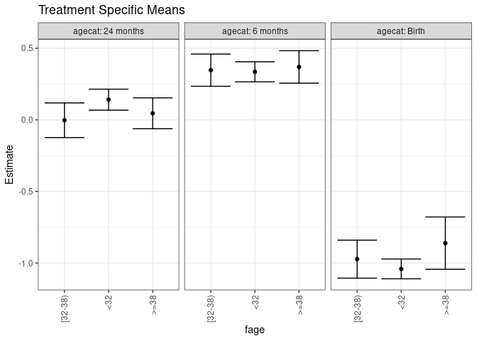

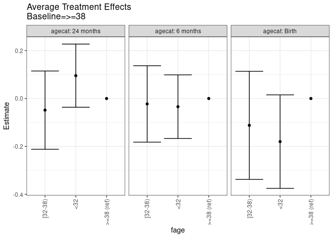

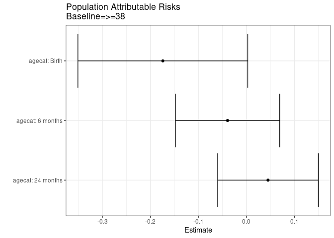

## Results Table

### Parameter: TSM

| agecat | intervention_level | baseline_level | estimate | ci_lower | ci_upper |
| --- | --- | --- | --- | --- | --- |
| Birth | >=38 | NA | -0.8610533 | -1.0437186 | -0.6783879 |
| Birth | <32 | NA | -1.0409035 | -1.1099592 | -0.9718478 |
| Birth | [32-38) | NA | -0.9728472 | -1.1053532 | -0.8403411 |
| 6 months | >=38 | NA | 0.3695949 | 0.2561945 | 0.4829953 |
| 6 months | <32 | NA | 0.3355477 | 0.2653994 | 0.4056959 |
| 6 months | [32-38) | NA | 0.3470815 | 0.2346237 | 0.4595393 |
| 24 months | >=38 | NA | 0.0456711 | -0.0620540 | 0.1533963 |
| 24 months | <32 | NA | 0.1410292 | 0.0676177 | 0.2144406 |
| 24 months | [32-38) | NA | -0.0027953 | -0.1238675 | 0.1182769 |

### Parameter: E(Y)

| agecat | intervention_level | baseline_level | estimate | ci_lower | ci_upper |
| --- | --- | --- | --- | --- | --- |
| Birth | NA | NA | -1.0351384 | -1.0763260 | -0.9939508 |
| 6 months | NA | NA | 0.3304061 | 0.2971216 | 0.3636906 |
| 24 months | NA | NA | 0.0907567 | 0.0612872 | 0.1202262 |

### Parameter: ATE

| agecat | intervention_level | baseline_level | estimate | ci_lower | ci_upper |
| --- | --- | --- | --- | --- | --- |
| Birth | >=38 | >=38 | 0.0000000 | 0.0000000 | 0.0000000 |
| Birth | <32 | >=38 | -0.1798502 | -0.3748929 | 0.0151925 |
| Birth | [32-38) | >=38 | -0.1117939 | -0.3372068 | 0.1136190 |
| 6 months | >=38 | >=38 | 0.0000000 | 0.0000000 | 0.0000000 |
| 6 months | <32 | >=38 | -0.0340473 | -0.1668510 | 0.0987565 |
| 6 months | [32-38) | >=38 | -0.0225134 | -0.1819273 | 0.1369005 |
| 24 months | >=38 | >=38 | 0.0000000 | 0.0000000 | 0.0000000 |
| 24 months | <32 | >=38 | 0.0953580 | -0.0365084 | 0.2272245 |
| 24 months | [32-38) | >=38 | -0.0484664 | -0.2117211 | 0.1147882 |

### Parameter: PAR

| agecat | intervention_level | baseline_level | estimate | ci_lower | ci_upper |
| --- | --- | --- | --- | --- | --- |
| Birth | >=38 | NA | -0.1740852 | -0.3510644 | 0.0028941 |
| 6 months | >=38 | NA | -0.0391888 | -0.1478526 | 0.0694750 |
| 24 months | >=38 | NA | 0.0450856 | -0.0597728 | 0.1499440 |